# Entrance, duration of contracts, accumulated experience

Adam Finnemann

October 19, 2017

```r
library(pacman)
```

```r
p_load("strmingr","ggplot2","ggExtra","lmerTest","tidyverse", "zoo","lubridate", "data.table", "ggthemes")
setwd("~/Historie projekt/historie project/LONSEA_DB/spring18/proportion_of_scandis")

da <- read.csv(list.files(pattern = "contract_"))
```

## Question: Relative proportion of Scandinavians in section

Question from Torsten: The first one is about the relative representation of the Scandinavian members of section (including directors, chiefs and experts/specialists).We want to know in per centage, which proportion of the Secretariat staff the Scandinavians made up, year by year, over time. It is basically this graph, where you counted, how many members were in the Secretariat at a certain point of time.

Overview of nationalities. 344 contracts are missing nationalities

```r
summary(da$nationality)
```

```
##                                    Albanian         AlbanianSwiss
##                   344                     5                     3
##           Argentinian              Armenian            Australian
##                     8                     2                    24
##              Austrian              Bolivian             Brazilian
##                    44                     3                     3
##               British          BritishSwiss             Bulgarian
##                   390                     1                    15
##              Canadian               Chilean               Chinese
##                    26                     4                    22
##           Costa_Rican                 Cuban                 Czech
##                     3                     4                    43
##                  Dane              Danziger                 Dutch
##                    41                     2                    61
##            DutchSwiss              Egyptian               English
##                     1                     4                  1012
##          English,Dane   English,US-American              Estonian
##                     1                     2                     7
##                Finish                French French,British, Swiss
##                    12                   978                     1
##        French,Italian           FrenchSwiss                German
##                     1                     1                   101
##                 Greek            Guatemalan               Haitian
##                    27                     2                     1
##             Hungarian             Icelander                Indian
##                    27                     2                    43
##               Iranian                 Iraqi                 Irish
##                     7                     6                    55
##               Italian       Italian,English          ItalianSwiss
##                   297                     1                     6
##              Japanese               Latvian          LatvianSwiss
##                     4                    13                     1
##            Lithuanian         Luxembourgish               Mexican
##                    14                    13                     4
##         New_Zealander             Norwegian            Panamanian
##                    14                    36                     3
##            Paraguayan               Persian              Peruvian
##                     2                     3                     8
##                Polish             Portugese              Romanian
##                    59                     9                    25
##               Russian       Russian,British          RussianSwiss
##                    21                     1                     2
##           Salvadorian               Siamese         South_African
##                     1                     2                    12
##               Spanish               Swedish                 Swiss
##                    32                    30                  2297
##        Swiss,Armenian         Swiss,British         Swiss,English
##                     5                    13                     8
##          Swiss,French          Swiss,German          Swiss,Syrian
##                     6                     1                     1
##        Swiss,Yugoslav                Syrian                  Thai
##                     1                     1                     1
##               Turkish             Uruguayan           US-American
##                     8                     3                    61
##            Venezuelan              Yugoslav
##                     6                    36
```

there are 98 contracts from first division missing nationality. In my opinion none of the names looked very scandinavian beside a secretary called “Dagny Gran”

```r
important_w_missing_nat = da %>%
  filter(nationality == "" & canonical_fname == "First Division")
important_w_missing_nat$pname
```

```
##  [1] Chikao/Chikas Fujisawa
##  [2] Setsuichi Aoki
##  [3] Setsuichi Aoki
##  [4] Pierre Waelbroeck-Rolin
##  [5] Maurice Naessens
##  [6] Cuno de Watteville
##  [7] Marcel Guillaume Jacques Wiser
##  [8] Joseph Hippolyte Marie Ghislain Nisot
##  [9] Philip John Noel-Baker
## [10] Philip John Noel-Baker
## [11] M. Nyns-Lagye
## [12] Anna Teresa Paradas
## [13] Alex Paternotte
## [14] F. McBryan
## [15] Professor Anath Nath Basu
```

[output cut: 84 more lines]

Subsetting scandinavians: defined as Danes, Swedes and Norwegians.

```r
scandi = da %>%
  filter(nationality %in% c("Dane", "Swedish","Norwegian"))
```

107 contract belonging to Scandinavians are found

Further subset, including only Scandinavians with fname of Section, Chiefs, experts and directors.Secretary of section is excluded.

```r
top_scandi <- scandi %>%
  filter(str_detect(scandi$fname, "Section") | str_detect(scandi$fname, "Director") | str_detect(scandi$fname, "Chief") | str_detect(scandi$fname, "Expert"),
         fname != "Secretary of Section")
#unique(droplevels(top_scandi$pname))
```

27 contracts from 21 different people are found

```r
#employment interval function
employment <- function(df, interval = "1 year"){

mdl_df <- df %>%
  select(pname, fname_code,begin_date, end_date) %>%
  mutate(begin_date = as.Date(begin_date),
         end_date = as.Date(end_date))



result <- setDT(mdl_df)[
  .(mseq = seq(as.Date("1919-01-01"), as.Date("1949-12-30"), by = interval)),
  on = .(begin_date <= mseq, end_date >= mseq), nomatch = 0L, allow.cartesian = TRUE][
    , dcast(unique(.SD), pname ~ end_date, toString, value.var = "fname_code")]
}
```

```r
scandi_res <- employment(top_scandi)
```

```r
p <- top_scandi[which(!top_scandi$pname %in% scandi_res$pname),]
p
```

```
##   X.1    X   id                     pname gender             fname
## 7 267 6406 5042 Oscar Uno Konrad Thorsing      0 Member of Section
##   canonical_fname               oname born_on_year begin_on_year
## 7  First Division Information Section         1896          1925
##   begin_on_month begin_on_day end_on_year end_on_month end_on_day
## 7             10            1        1924           12         31
##   nationality fname_code begin_date   end_date
## 7     Swedish          8 1925-01-01 1924-01-01
```

One contract beloning to Oscar Uno Konrad Thorsing is removed during the analysis since begin_on_year is later than his end_on_year.

calculating number of scandinavians in section per year

```r
top_scandi <- scandi_res%>%
  summarise_all(function(x) sum(x != ""))

long_scandi <- gather(top_scandi, key, value, `1919-01-01`:`1946-01-01`) %>%
  mutate(key = as.Date(key))

names(long_scandi) = c("strange","Year", "number_of_scandis")

long_scandi = long_scandi %>%
  select(Year, number_of_scandis)

#write.csv(long_scandi, "scandis_in_section_table.csv")

long_scandi
```

```
##          Year number_of_scandis
## 1  1919-01-01                 1
## 2  1920-01-01                 4
## 3  1921-01-01                 7
## 4  1922-01-01                 7
## 5  1923-01-01                 8
## 6  1924-01-01                 9
## 7  1925-01-01                 8
## 8  1926-01-01                 8
## 9  1927-01-01                 8
## 10 1928-01-01                 8
## 11 1929-01-01                 7
## 12 1930-01-01                 7
## 13 1931-01-01                 9
## 14 1932-01-01                 8
## 15 1933-01-01                 8
## 16 1934-01-01                 7
## 17 1935-01-01                 7
## 18 1936-01-01                 8
## 19 1937-01-01                 8
## 20 1938-01-01                 9
## 21 1939-01-01                10
## 22 1940-01-01                 5
## 23 1941-01-01                 4
## 24 1942-01-01                 4
## 25 1943-01-01                 3
## 26 1944-01-01                 3
## 27 1945-01-01                 4
## 28 1946-01-01                 4
```

Calculating total number of wokres in section, directors, experts and chiefs.

```r
top_people <- da %>%
  filter(str_detect(scandi$fname, "Section") | str_detect(scandi$fname, "Director") | str_detect(scandi$fname, "Chief") | str_detect(scandi$fname, "Expert"),
         fname != "Secretary of Section")
length(unique(droplevels(top_people$pname)))
```

```
## [1] 1211
```

1618 contracts from 1211 different individuals are found

```r
result = employment(top_people)
```

4 people are removed during the analysis since their begin_on_year is later than their end_on_year.

```r
p <- top_people[which(!top_people$pname %in% result$pname),]
p
```

```
##     X.1    X   id                     pname gender                  fname
## 17   47 6115 4861       Francis Yeats-Brown      0 Temporary Collaborator
## 74  267 6406 5042 Oscar Uno Konrad Thorsing      0      Member of Section
## 77  273 6412 5048          Elisabeth Toelpe      1 Temporary Collaborator
## 179 689 6922 5403      Edward Albert Radice      0      Expert/Specialist
##     canonical_fname                          oname born_on_year
## 17   First Division            Information Section           NA
## 74   First Division            Information Section         1896
## 77   First Division            Information Section           NA
## 179  First Division Economic and Financial Section           NA
##     begin_on_year begin_on_month begin_on_day end_on_year end_on_month
## 17           1927             12            1        1921           12
## 74           1925             10            1        1924           12
## 77           1930              9            8        1929            9
## 179          1939              4           22        1930            9
##     end_on_day nationality fname_code begin_date   end_date
## 17          21     English          8 1927-01-01 1921-01-01
## 74          31     Swedish          8 1925-01-01 1924-01-01
## 77          29      German          8 1930-01-01 1929-01-01
## 179         24     English          8 1939-01-01 1930-01-01
```

I run the analysis in period 1919 to 1946. This is the period with scandinavians. However, in 1947 there are still 9 non-scandinavians left in the sections,

```r
top_workers <- result%>%
  summarise_all(function(x) sum(x != ""))

long_work <- gather(top_workers, key, value, `1919-01-01`:`1946-01-01`) %>%
  mutate(key = as.Date(key))

names(long_work) = c("strange1","strange2", "Year", "number_of_workers")
long_work = long_work %>%
  select(Year, number_of_workers)

#write.csv(long_work, "total_workers_in_section_table.csv")

long_work
```

```
##          Year number_of_workers
## 1  1919-01-01                29
## 2  1920-01-01               110
## 3  1921-01-01               157
## 4  1922-01-01               175
## 5  1923-01-01               177
## 6  1924-01-01               187
## 7  1925-01-01               193
## 8  1926-01-01               217
## 9  1927-01-01               230
## 10 1928-01-01               256
## 11 1929-01-01               265
## 12 1930-01-01               311
## 13 1931-01-01               310
## 14 1932-01-01               290
## 15 1933-01-01               252
## 16 1934-01-01               232
## 17 1935-01-01               234
## 18 1936-01-01               277
## 19 1937-01-01               301
## 20 1938-01-01               284
## 21 1939-01-01               219
## 22 1940-01-01               160
## 23 1941-01-01                55
## 24 1942-01-01                49
## 25 1943-01-01                47
## 26 1944-01-01                48
## 27 1945-01-01                48
## 28 1946-01-01                98
```

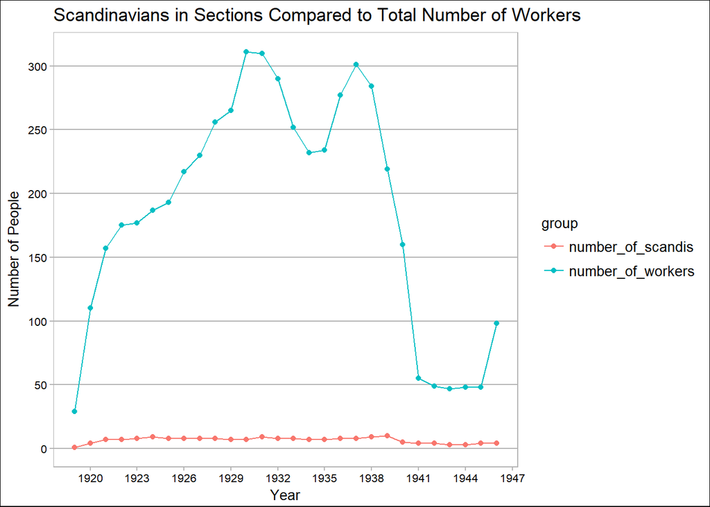

```r
plot_df = merge(long_work, long_scandi, by = "Year")

long_plot_df = plot_df %>%
gather(group, number,number_of_scandis, number_of_workers)


long_plot_df %>%
  ggplot(aes(x = Year, y = number, color = group)) +
  geom_point() +
  geom_line() +
  scale_x_date(date_breaks = "3 year", date_labels = "%Y") +
  scale_y_continuous(breaks = seq(0,300,50))+
  labs(x = "Year", y ="Number of People", titles = "Scandinavians in Sections Compared to Total Number of Workers")+
  theme_calc()
```

calculating proportion of scandinavians per year

```r
plot_df = plot_df %>%
  mutate(proportion = number_of_scandis / number_of_workers)

plot_df$proportion
```

```
##  [1] 0.03448276 0.03636364 0.04458599 0.04000000 0.04519774 0.04812834
##  [7] 0.04145078 0.03686636 0.03478261 0.03125000 0.02641509 0.02250804
## [13] 0.02903226 0.02758621 0.03174603 0.03017241 0.02991453 0.02888087
## [19] 0.02657807 0.03169014 0.04566210 0.03125000 0.07272727 0.08163265
## [25] 0.06382979 0.06250000 0.08333333 0.04081633
```

generally scandinavians make up 3-8 % of the section. The development is visualized

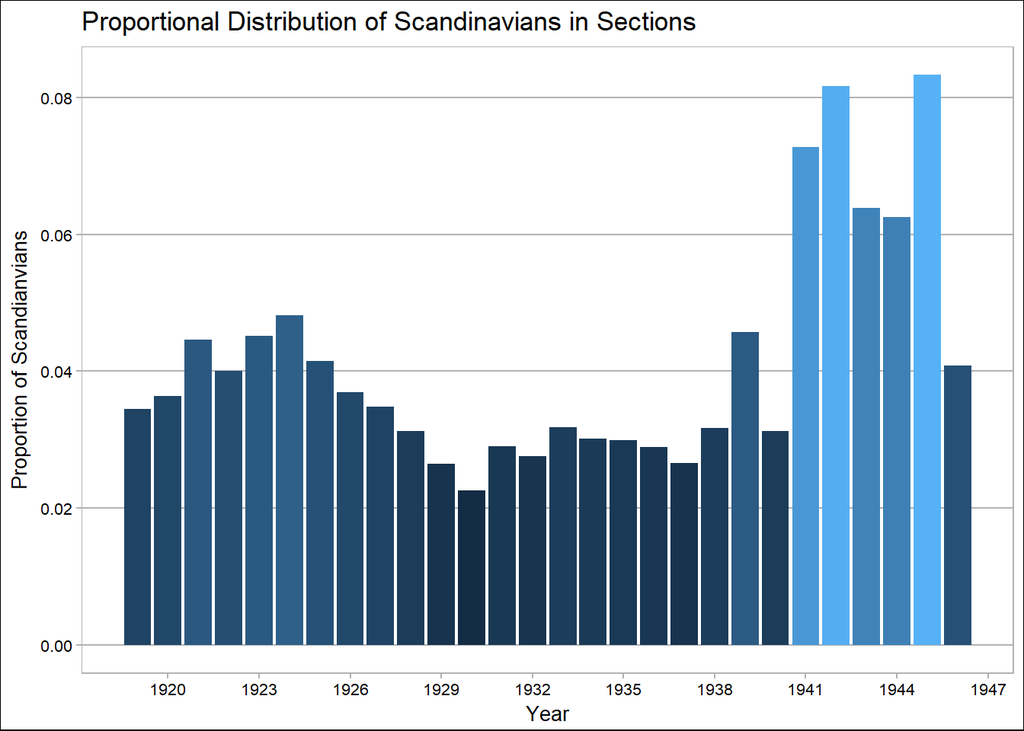

```r
plot_df %>%
  ggplot(aes(Year, proportion, fill = proportion)) +
  geom_col() +
  scale_x_date(date_breaks = "3 year", date_labels = "%Y") +
  theme_calc() +
  theme(legend.position="none")+
  labs(x = "Year", y ="Proportion of Scandianvians", titles = "Proportional Distribution of Scandinavians in Sections")
```

saving table with numbers

```r
#write.csv(plot_df, "scandi_comparison.csv")
```